# LAB4

Laura Sudupe

9/11/2020

EJERCICIO 1. a) Si X es una v.a. con distribución normal de media 3,5 y desviación típica 0,5 ¿cuál es la probabilidad de que X sea menor que 4?

```r
#probabilidad de que X sea 4 o menos
prop_norm <- pnorm(4, mean=3.5, sd=0.5, lower.tail = TRUE)
#prob de que sea 4
prob_norm_4 <- dnorm(4, mean=3.5, sd=0.5)
#probabilidad x <4
prob_menos_4 <- prop_norm -prob_norm_4
```

2. Generad una muestra de tamaño 100 para una población normal de media 10 y desviación típica igual a 1. Guardad el resultado en un vector llamado v.

```r
muestra <- rnorm(100, mean=10, sd=1)
summary(muestra)
```

```
##    Min. 1st Qu.  Median    Mean 3rd Qu.    Max.
##   6.863   9.284   9.968   9.966  10.879  12.446
```

```r
muestr <- c(rnorm(100, mean=10, sd=1))
summary(muestr)
```

```
##    Min. 1st Qu.  Median    Mean 3rd Qu.    Max.
##   7.576   9.343  10.081  10.051  10.754  12.246
```

3. Comprobad que la muestra tenga una media y una desviación típica aproximada a la del enunciado del apartado anterior.
4. Comprobad con un gráfico que esta muestra tenga una distribución normal.

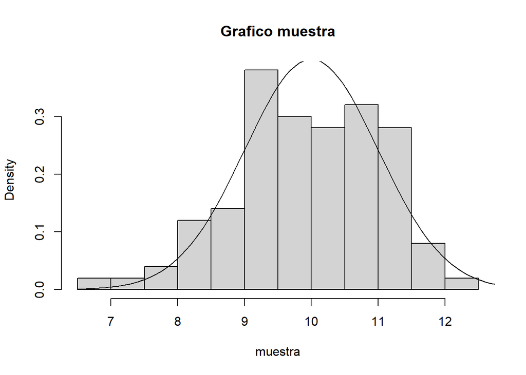

```r
hist(muestra, freq = FALSE, main= "Grafico muestra")
curve(dnorm(x, mean = 10, sd =1), from = 6.5, to = 13, add =TRUE)
```

EJERCICIO 2. Generad 200 observaciones de una distribución binomial,B(1, 0.5) y guardadlo en un vector llamado «bino».

```r
set.seed(9991)
bino <- rbinom(200,1,0.5)
summary(bino)
```

```
##    Min. 1st Qu.  Median    Mean 3rd Qu.    Max.
##    0.00    0.00    0.00    0.48    1.00    1.00
```

Calculad las frecuencias absolutas y relativas de los valores generados en el vector anterior. ¿Qué observáis con el resultado que habéis obtenido?

```r
freq <- table(bino)
prop.table(freq)
```

```
## bino
##    0    1
## 0.52 0.48
```

EJERCICIO Distribución binomial. a) Calcular la probabilidad de obtener cuatro caras al lanzar seis veces una moneda perfecta.

```r
dbinom(x=4, size=6, prob=0.5)
```

```
## [1] 0.234375
```

2. Calcular la probabilidad de obtener como mucho cuatro caras al lanzar seis veces una moneda perfecta.

```r
pbinom(4,6,0.5)
```

```
## [1] 0.890625
```

3. Generar 10 valores seudoaleatorios de una B(6,0.5).

```r
rbinom(10,6,0.5)
```

```
##  [1] 4 4 3 3 2 4 1 3 3 1
```

EJERCICIO Distribución Poisson. Supongamos que estamos en una fábrica de telas que realiza un número de telas por minuto y que sigue una distribución de Poisson con parámetro ʎ = 0.5. Determinar: a) La probabilidad de que, en un minuto al azar, se genere una única tela.

```r
dpois(c(1), 0.5)
```

```
## [1] 0.3032653
```

2. La probabilidad de que, en un minuto al azar, se generen un máximo de 3 telas.

```r
ppois(c(3), 0.5)
```

```
## [1] 0.9982484
```

3. La probabilidad de que se generen cinco telas en 4 minutos.

```r
dpois(c(5), 2)
```

```
## [1] 0.03608941
```

EJERCICIO Distribución normal. a) Generar una muestra de tamaño 1000 de una distribución normal N(3,2).

```r
set.seed(9991)
normal <- rnorm(1000, mean = 3, 2)
summary(normal)
```

```
##    Min. 1st Qu.  Median    Mean 3rd Qu.    Max.
##  -3.020   1.708   3.014   3.078   4.462  10.196
```

2. Crear el histograma de la muestra.

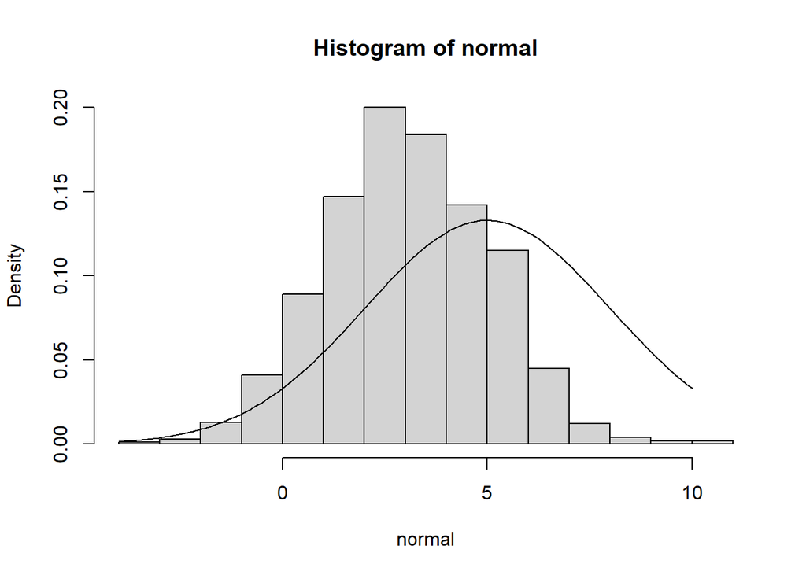

```r
hist(normal, freq = F)
curve(dnorm(x, 5, 3), -4, 10, add =T)
```

EJERCICIO 3. La teoría nos dice que si X1 y X2 son variables independientes que siguen una distribución normal, la suma de las dos variables también será una distribución normal. Para comprobarlo, deberemos simular dos muestras de X1 y X2 de tamaño 100000 y sumarlas para ver si la función de densidad de la distribución conjunta de su suma también sigue una distribución normal. Las características de cada variable son: x1~N(6, 0.5) y x2~N(3, 0.6)

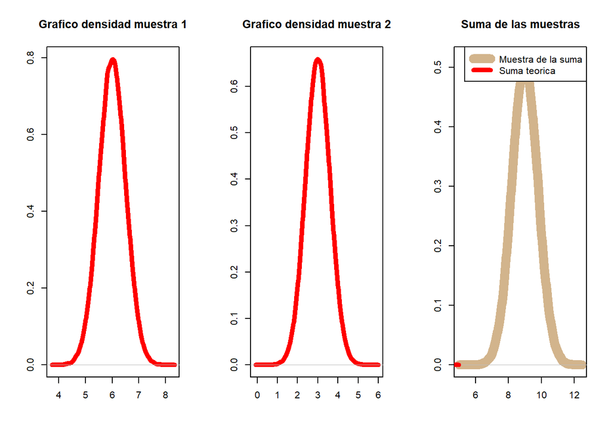

```r
muestra1 <- rnorm(100000, mean=6, sd=0.5)
muestra2 <- rnorm(100000, mean=3, sd=0.6)
par(mfrow=c(1,3))
plot(density(muestra1), col="red", main="Grafico densidad muestra 1", xlab= "",
     ylab="", lwd=5)
plot(density(muestra2), col="red", main="Grafico densidad muestra 2", xlab= "",
     ylab="", lwd=5)


suma <- muestra1 + muestra2
#grafico de densidad de la suma de las variables simuladas
{plot(density(suma), col= 'tan', main="Suma de las muestras", xlab= "", ylab= "",
     lwd=10)
#para añadirle la leyenda
legend("topright", c("Muestra de la suma", "Suma teorica"), col=c("tan", "red")
       , lwd=c(10, 5))

curve(dnorm(x, mean=9, sd = sqrt(0.25+0.36)), from= -1, to= 5, add = TRUE,
      100000, col="red", lwd=5)}
```

EJERCICIO 4. Simulación Montecarlo Echamos al aire una moneda 10 veces y queremos saber la probabilidad de que salga cara mas de 3 veces. Podemos hacerlo con el metodo Montecarlo. Simulamos 10 lanzamientos 100,000 veces y vemos cuantas veces pasa.

```r
tandas <- 100000

#una_tanda simula una ronda de 10 veces y retorna true si el numero de caras
#es mayor que 3. Cruz=0, cara=1.

una_tanda <- function(){
  sum(sample(c(0,1),10,replace=T)) > 3
}

#ahora repetimos la ronda un numero "tandas" de veces
mc.binom <- sum(replicate(tandas, una_tanda()))/tandas

#comparamos con lo obtenido con la funcion de distribución binomial
distr_bi <- pbinom(3,10,0.5,lower.tail=FALSE)
```